# Working with data.table

Michael Love

11/5/2018

# Introduction

In this first lecture note on dealing with large datasets in R, we will introduce a specialized package for manipulating large tables of data, called *data.table*. For some background material, see the following links. The first link has useful speed comparisons with other packages as well as a table of basic operations, some of which we will cover in this lecture note, but others which go beyond what we cover here.

- [data.table website](https://github.com/Rdatatable/data.table/wiki)
- [data.table CRAN page](https://cran.r-project.org/web/packages/data.table/)

To motivate why we start with *data.table*, I refer to the following sections of the book, [Efficient R Programming](https://csgillespie.github.io/efficientR), by Colin Gillespie and Robin Lovelace which was mentioned earlier in the course:

- [Efficient input/output: plain text formats](https://csgillespie.github.io/efficientR/input-output.html#fread)
- [Efficient data carpentry: Data processing with data.table](https://csgillespie.github.io/efficientR/data-carpentry.html#data-processing-with-data.table)

We will also discuss data input and data processing below.

# Reading large data from plain text

One of the initial hurdles for working with large datasets is simply reading in the data. *data.table* has a fast implementation `fread` for *fast read*. Start by reading the help for `fread`:

```r
?fread
```

Note that it has a number of arguments, some of which are not the same as base R’s `read.table`, e.g. `stringsAsFactors=FALSE` and `sep="auto"`. A natural comparison is `fread` vs the `read_csv` and `read_tsv` functions in the *readr* package. In the first *Efficient R Programming* link above, these are compared and they state that for large files, e.g. > 100Mb, the `fread` and `read_csv` functions are about equal, and 5x faster than base R’s `read.csv`.

Let’s compare *fread* and *read.csv* on a large file we will work with throughout the course, the *College Scorecard* dataset.

# Reading in College Scorecard dataset

Briefly, the [College Scorecard](https://collegescorecard.ed.gov/data/) dataset is compiled by the Department of Education and has the following descriptive paragraph from their website:

> The College Scorecard project is designed to increase transparency, putting the power in the hands of students and families to compare how well individual postsecondary institutions are preparing their students to be successful. This project provides data to help students and families compare college costs and outcomes as they weigh the tradeoffs of different colleges, accounting for their own needs and educational goals. These data are provided through federal reporting from institutions, data on federal financial aid, and tax information. These data provide insights into the performance of institutions that receive federal financial aid dollars, and the outcomes of the students of those institutions

We will discuss this dataset in more detail later, when we begin to model and find associations in the data, but for now just consider it as a large dataset (4.5 Gb uncompressed) in a series of comma-separated value (CSV) files.

We have downloaded the dataset from the website, and combined a number of the CSV files into a single file `Scorecard_2009-2016.csv`. This file is constructed via the following shell commands:

```
for i in `ls MERGED201*`; do echo $i; tail -n +2 $i > ${i/.csv}_nohead.csv; done
cp MERGED2009_10_PP.csv MERGED2009_head.csv
cat MERGED*head.csv > Scorecard_2009-2016.csv
```

The merged file has 60,307 rows (including a column header) and 1899 columns. To demonstrate the speed of `fread`, we will try just reading a subset of the full dataset. We can see that just on the first 10,000 rows, `fread` is more than 3x faster than *read.csv*:

```r
library(data.table)
n <- 10000
file <- "CollegeScorecard_Raw_Data/Scorecard_2009-2016.csv"
system.time({
  scores <- fread(file, nrows=n)
})
```

```
##    user  system elapsed
##   4.616   0.120   4.737
```

```r
system.time({
  scores2 <- read.csv(file, nrows=n)
})
```

```
##    user  system elapsed
##  15.849   0.096  15.946
```

The output is a bit different as well:

```r
class(scores)
```

```
## [1] "data.table" "data.frame"
```

```r
class(scores2)
```

```
## [1] "data.frame"
```

# Data manipulation with data.table

Some syntax is shared with *data.frame* but there are also additional operations that are specially designed for speed and for reduced keystrokes. Here, `NUMBRANCH` is a column of the *data.table* and so we can pull out certain rows by invoking the column name without having to write `scores$NUMBRANCH`. This gives the scores which have more than 25 branches:

```r
z <- scores[NUMBRANCH > 25]
nrow(z)
```

```
## [1] 253
```

A preview to later, we could have also gotten this number with some special *data.table* code, where `.N` gives us the number of rows:

```r
scores[NUMBRANCH > 25, .N]
```

```
## [1] 253
```

We can also pull out rows by matching on a string:

```r
scores[INSTNM == "University of North Carolina at Chapel Hill",1:20]
```

```
##    UNITID    OPEID OPEID6                                      INSTNM
## 1: 199120 00297400   2974 University of North Carolina at Chapel Hill
##           CITY STABBR   ZIP ACCREDAGENCY INSTURL NPCURL SCH_DEG HCM2 MAIN
## 1: Chapel Hill     NC 27599         NULL    NULL   NULL       3 NULL    1
##    NUMBRANCH PREDDEG HIGHDEG CONTROL ST_FIPS REGION LOCALE
## 1:         1       3       4       1      37      5   NULL
```

We can also specify a column to be a *key* for the *data.table*. Specifying a key allows very fast subsetting based on the column you specify. Here, because the key is an integer, we wrap up the key in `.()`, otherwise it would interpret our request as a row number:

```r
setkey(scores, UNITID)
scores[.(199120),1:20]
```

```
##    UNITID    OPEID OPEID6                                      INSTNM
## 1: 199120 00297400   2974 University of North Carolina at Chapel Hill
##           CITY STABBR   ZIP ACCREDAGENCY INSTURL NPCURL SCH_DEG HCM2 MAIN
## 1: Chapel Hill     NC 27599         NULL    NULL   NULL       3 NULL    1
##    NUMBRANCH PREDDEG HIGHDEG CONTROL ST_FIPS REGION LOCALE
## 1:         1       3       4       1      37      5   NULL
```

It happens that the *Id* column of this dataset is an integer, but we could also have made a string into the key:

```r
setkey(scores, CITY)
scores["Chapel Hill",1:20]
```

```
##    UNITID    OPEID OPEID6                                      INSTNM
## 1: 199120 00297400   2974 University of North Carolina at Chapel Hill
## 2: 455141 04140700  41407                 Aveda Institute-Chapel Hill
##           CITY STABBR        ZIP ACCREDAGENCY INSTURL NPCURL SCH_DEG HCM2
## 1: Chapel Hill     NC      27599         NULL    NULL   NULL       3 NULL
## 2: Chapel Hill     NC 27514-7001         NULL    NULL   NULL       1 NULL
##    MAIN NUMBRANCH PREDDEG HIGHDEG CONTROL ST_FIPS REGION LOCALE
## 1:    1         1       3       4       1      37      5   NULL
## 2:    1         1       1       1       3      37      5   NULL
```

As you can see the key does not have to be unique (unlike row names in R which must be unique). Subsetting with a key column using *data.table* is much faster than subsetting via other methods. The [Data processing with data.table](https://csgillespie.github.io/efficientR/data-carpentry.html#data-processing-with-data.table) chapter of the *Efficient R Programming* book shows that subsetting a *data.table* by key is more than 60x faster than base R *data.frame* and more than 40x faster than using *dplyr*. The *data.table* [website](https://github.com/Rdatatable/data.table/wiki) also has updated speed comparisons of *data.table* to *pandas* and *dplyr*, and included *Spark* and *pydatatable*, so you can get a sense of how different operations may differ across these packages. But the main takeaway should be that *data.table* is fast and if you have large datasets, you shouldn’t be using *data.frame* and base R functions for subsetting or grouping and summarization.

# Functions inside the brackets

We can put functions inside of the square brackets.

We first convert `TUITFTE` to numeric, which gives a warning about NAs introduced in the coercion step:

```r
scores$TUITFTE <- as.numeric(scores$TUITFTE)
```

```
## Warning: NAs introduced by coercion
```

Here a trivial example, to calculate the mean of the tuition per FTE (full-time equivalent) student.

```r
scores[,mean(TUITFTE,na.rm=TRUE)]
```

```
## [1] 8392.371
```

To make this a little easier to read, let’s define our own functions:

```r
mean2 <- function(x) mean(x, na.rm=TRUE)
q25 <- function(x) quantile(x, .25, na.rm=TRUE)
q50 <- function(x) quantile(x, .50, na.rm=TRUE)
q75 <- function(x) quantile(x, .75, na.rm=TRUE)
```

Now again. This example is trivial as we could just as well computed the function after having extracted the column:

```r
scores[,mean2(TUITFTE)]
```

```
## [1] 8392.371
```

```r
mean2(scores$TUITFTE)
```

```
## [1] 8392.371
```

# Grouping operations

The power of putting the function inside the square brackets is that it can be combined easily with subsetting and grouping operations. For example:

```r
scores[CONTROL==1,mean2(TUITFTE)]
```

```
## [1] 3482.954
```

Or with a grouping operation:

```r
scores[,mean2(TUITFTE),by=CONTROL]
```

```
##    CONTROL        V1
## 1:       3  8899.570
## 2:       1  3482.954
## 3:       2 12981.861
```

```r
scores[,.(median=q50(TUITFTE),q25=q25(TUITFTE),q75=q75(TUITFTE)),by=CONTROL]
```

```
##    CONTROL  median     q25      q75
## 1:       3  7621.5 4823.25 11503.25
## 2:       1  2549.0 1381.00  4635.00
## 3:       2 11631.5 7775.00 16654.25
```

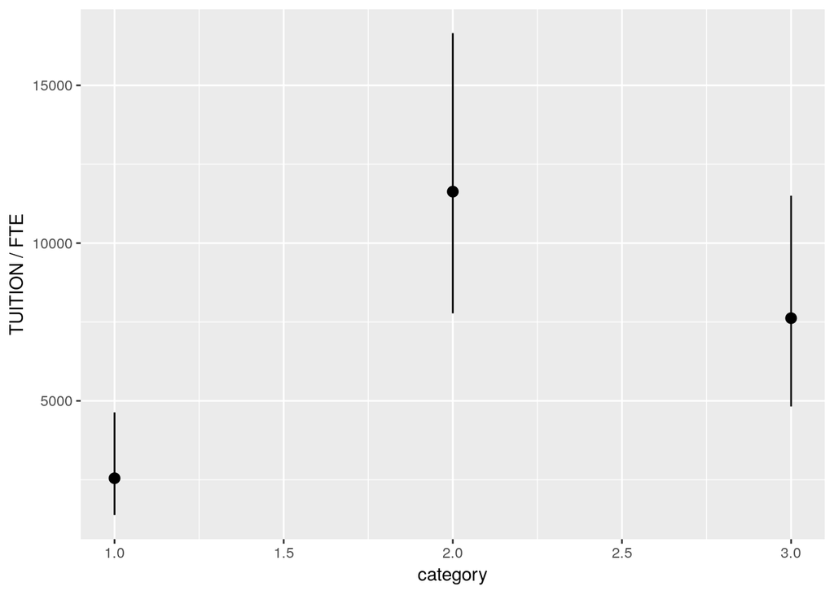

```r
library(ggplot2)
dat <- scores[,.(median=q50(TUITFTE),q25=q25(TUITFTE),q75=q75(TUITFTE)),by=CONTROL]
ggplot(dat, aes(CONTROL, median, ymin=q25, ymax=q75)) + geom_pointrange() +
  xlab("category") + ylab("TUITION / FTE")
```

Again, there are other complex functionality that can be performed with *data.table*, which can be looked over at the [data.table website](https://github.com/Rdatatable/data.table/wiki), but the operations above cover some of the most common use cases for reading, subsetting and computing on a large tabular dataset.